# Variable Selection: RFs w/biovars, HWSD, CDL, & farm(er) characteristics

Britta Schumacher

Last updated: 26 July, 2021

# Data prep

## Load data

```r
library(tidyverse)
library(ggcorrplot)
```

### Reduce panel to only counties where yield is reported in a county-year

```r
yield <- readRDS("./data/true-train.RDS")
yield <- as.data.frame(yield)

yield <- yield %>% filter(!is.na(YIELD)) # reduces to 16983 unique county-year observations

# add farm(er) characteristics
farm <- readRDS("./data/farm-er-interp.RDS")

farm <- farm %>% select(!county)

yield <- merge(yield, farm, by = c("GEOID", "YEAR"))
```

# Variable selection

```r
#find % available
data_avail <- yield %>%
  summarize_all(funs(sum(is.na(.)) / length(.)))
#if you want to transpose, use the code below
t_d <- t(data_avail)
```

### Remove missing variables – these are also more difficult to interpret/qualitative soil variables that are a bit redundant and ranked by J. Cowan as 2-3 (medium to low priority)

```r
yield <- yield %>% dplyr::select(-c("PHASE1", "DRAINAGE", "T_USDA_TEX_CLASS", "T_TEXTURE", "REF_DEPTH", "AWC_CLASS", "ADD_PROP"))
```

### Remove variables that are linear products of other variables

```r
#BV3 is a direct product of BV2 and BV7
#BV7 is a direct product of BV5 and BV6
# perc_corn = CORN_SQKM/AG_SQKM*100
yield <- yield %>% dplyr::select(-c("BV3", "BV7", "AG_SQKM", "CORN_SQKM"))
```

### Pair-Wise Correlation Matrix ~ Soil

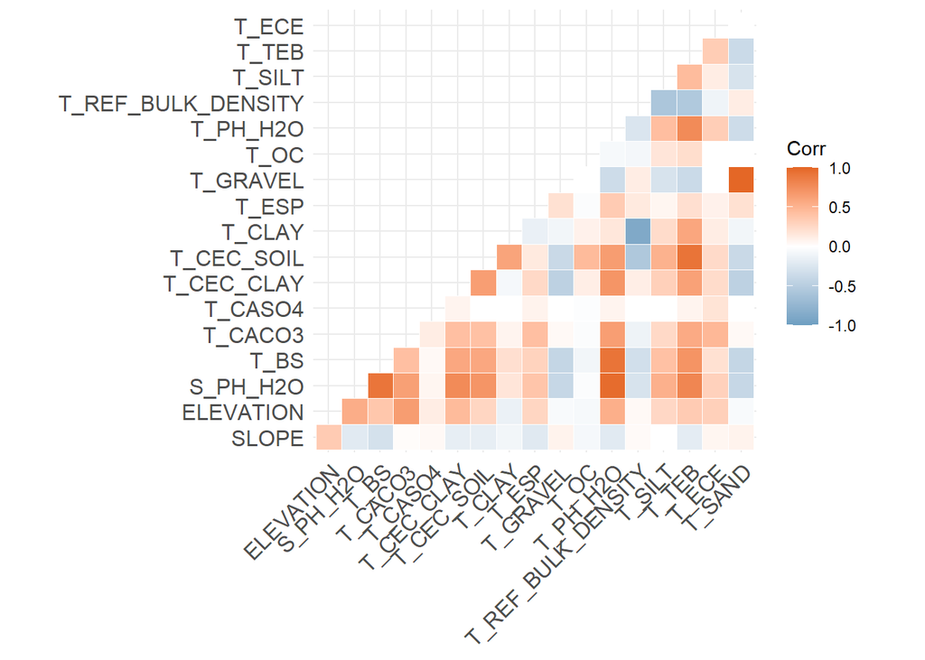

```r
# visualize by "natural" groupings of variables
# first, soil -- removing qualitative/coded variables T_TEXTURE, REF_DEPTH, DRAINAGE, AWC_CLASS, ADD_PROP, T_USDA_TEX_CLASS
soil <- yield[c(3:4,25:40)]
corr_soil <- round(cor(soil[c(1:18)]), 2)
p.mat_soil <- cor_pmat(soil[c(1:18)])
corrplot_soil <- ggcorrplot(corr_soil, hc.order = FALSE, p.mat = p.mat_soil, outline.col = "white", type = "lower", insig = "blank",lab = F, ggtheme = ggplot2::theme_minimal, colors = c("#6D9EC1", "white", "#E46726"))
corrplot_soil
```

```r
# see initial correlations
red_soil <- as.data.frame(as.table(cor(soil[c(1:18)]), 1))
red_soil <- red_soil %>%  filter(Freq != 1) %>% mutate(aFreq = abs(Freq)) %>% arrange(desc(aFreq)) %>% filter(aFreq > 0.80) %>% dplyr::select(c(Var1, Var2, Freq))

knitr::kable(red_soil, caption = "Soil variable pairs with high correlation")
```

Soil variable pairs with high correlation

| Var1 | Var2 | Freq |
| --- | --- | --- |
| T_PH_H2O | S_PH_H2O | 0.9688393 |
| S_PH_H2O | T_PH_H2O | 0.9688393 |
| T_PH_H2O | T_BS | 0.9249468 |
| T_BS | T_PH_H2O | 0.9249468 |
| T_TEB | T_CEC_SOIL | 0.9231450 |
| T_CEC_SOIL | T_TEB | 0.9231450 |
| T_BS | S_PH_H2O | 0.9116509 |
| S_PH_H2O | T_BS | 0.9116509 |
| T_REF_BULK_DENSITY | T_CLAY | -0.8802944 |
| T_CLAY | T_REF_BULK_DENSITY | -0.8802944 |
| T_TEB | S_PH_H2O | 0.8018084 |
| S_PH_H2O | T_TEB | 0.8018084 |

```r
# reduce redundant variables
red_soil_s1 <- as.data.frame(as.table(cor(soil[c(1:3,5:8,10:12,14:15,17:18)]), 1))
red_soil_s1 <- red_soil_s1 %>%  filter(Freq != 1) %>% mutate(aFreq = abs(Freq)) %>% arrange(desc(aFreq)) %>% filter(aFreq > 0.80) %>% dplyr::select(c(Var1, Var2, Freq))

# remove qualitative coded variables that lack information and save full soil list of interest
soil_quant <- as.data.frame(soil[c(1:3,5:8,10:12,14:15,17:18)])
soil_final_variables <- c("SLOPE","ELEVATION","S_PH_H2O","T_CACO3","T_CASO4","T_CEC_CLAY","T_CEC_SOIL","T_ESP","T_GRAVEL","T_OC","T_REF_BULK_DENSITY","T_SILT","T_ECE","T_SAND")
```

First, we’ll get rid of topsoil pH because this can be pretty variable over time in some places. Farmers actively manage for this in the midwest–but pretty time invariable in other places, like the intermountain west. Anyway, let’s toss it and see where that takes us. Let’s also get rid of T_TEB–J. Cowan prioritized this as a 2 (medium priority) v. T_CEC_SOIL (high priority) and S_PH_H2O (high priority); T_BS–J. Cowan prioritized this as a 2 (medium priority) v. S_PH_H20 (high priority). Let’s keep T_REF_BULK_DENSITY because it is an indication of how restricted root growth will be in a soil and changes as the percentage clay-silt-sand changes; so we’ll get rid of T_CLAY.

Drop:

- T_PH_H2O
- T_TEB
- T_BS
- T_CLAY
- ^REF_DEPTH
- ^T_TEXTURE
- ^DRAINAGE
- ^AWC_CLASS
- ^ADD_PROP
- ^T_USDA_TEX_CLASS

(^) Variables that do not match the elimination Emily did.

### Pair-Wise Correlation Matrix ~ Climate

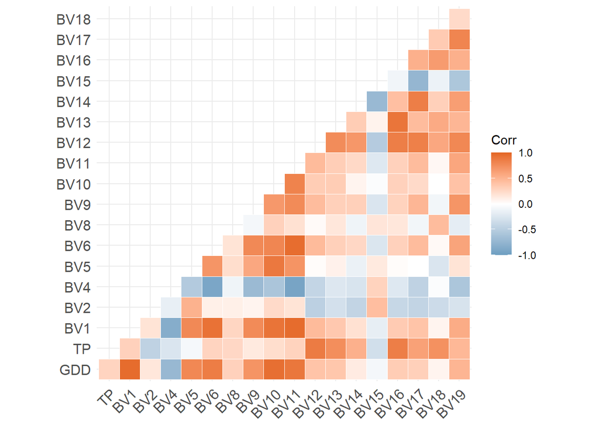

```r
library(ggcorrplot)
# visualize by "natural" groupings of variables
# second, climate --
climate <- yield[c(5:6,44:60)]
corr_clim <- round(cor(climate[c(1:19)]), 2)
p.mat_clim <- cor_pmat(climate[c(1:19)])
corrplot_clim <- ggcorrplot(corr_clim, hc.order = FALSE, p.mat = p.mat_clim, outline.col = "white", type = "lower", insig = "blank",lab = F, ggtheme = ggplot2::theme_minimal, colors = c("#6D9EC1", "white", "#E46726"))
corrplot_clim
```

```r
# see initial correlations
red_clim <- as.data.frame(as.table(cor(climate[c(1:19)]), 1))
red_clim <- red_clim %>%  filter(Freq != 1) %>% mutate(aFreq = abs(Freq)) %>% arrange(desc(aFreq)) %>% filter(aFreq > 0.80) %>% dplyr::select(c(Var1, Var2, Freq))

knitr::kable(red_clim, caption = "Climate variable pairs with high correlation")
```

Climate variable pairs with high correlation

| Var1 | Var2 | Freq |
| --- | --- | --- |
| BV11 | BV1 | 0.9678669 |
| BV1 | BV11 | 0.9678669 |
| BV1 | GDD | 0.9673570 |
| GDD | BV1 | 0.9673570 |
| BV11 | BV6 | 0.9632447 |
| BV6 | BV11 | 0.9632447 |
| BV10 | GDD | 0.9463448 |
| GDD | BV10 | 0.9463448 |
| BV11 | BV4 | -0.9344872 |
| BV4 | BV11 | -0.9344872 |
| BV6 | BV1 | 0.9339659 |
| BV1 | BV6 | 0.9339659 |
| BV10 | BV1 | 0.9213742 |
| BV1 | BV10 | 0.9213742 |
| BV16 | BV13 | 0.9105902 |
| BV13 | BV16 | 0.9105902 |
| BV6 | BV4 | -0.9084893 |
| BV4 | BV6 | -0.9084893 |
| BV11 | GDD | 0.9018632 |
| GDD | BV11 | 0.9018632 |
| BV10 | BV5 | 0.8857887 |
| BV5 | BV10 | 0.8857887 |
| BV12 | TP | 0.8698773 |
| TP | BV12 | 0.8698773 |
| BV6 | GDD | 0.8648892 |
| GDD | BV6 | 0.8648892 |
| BV16 | BV12 | 0.8509902 |
| BV12 | BV16 | 0.8509902 |
| BV16 | TP | 0.8492048 |
| TP | BV16 | 0.8492048 |
| BV17 | BV14 | 0.8487577 |
| BV14 | BV17 | 0.8487577 |
| BV17 | BV12 | 0.8415567 |
| BV12 | BV17 | 0.8415567 |
| BV4 | BV1 | -0.8405345 |
| BV1 | BV4 | -0.8405345 |
| BV11 | BV10 | 0.8230434 |
| BV10 | BV11 | 0.8230434 |
| BV19 | BV17 | 0.8136097 |
| BV17 | BV19 | 0.8136097 |
| BV10 | BV6 | 0.8030501 |
| BV6 | BV10 | 0.8030501 |

```r
# reduce redundant variables
red_clim_s1 <- as.data.frame(as.table(cor(climate[c(1:2,4:5,8:9,15,18:19)]), 1))
red_clim_s1 <- red_clim_s1 %>%  filter(Freq != 1) %>% mutate(aFreq = abs(Freq)) %>% arrange(desc(aFreq)) %>% filter(aFreq > 0.80) %>% dplyr::select(c(Var1, Var2, Freq))

# remove qualitative coded variables that lack information and save full soil list of interest
clim_quant <- as.data.frame(climate[c(1:2,4:5,8:9,15,18:19)])
climate_final_variables <- c("GDD","TP","BV2","BV4","BV8","BV9","BV15","BV18","BV19")
```

Drop - order removed - reason:

**Rules of elimination:

1. Drop any climate variable that measure a range, retain the min and max values
2. Drop any climate variable that is a monthly measurement and retain quarterly measurement
3. Drop any climate variable that is an annual summary
4. Keep crop-specific variables when collinear with biovars
- *BV1: Mean annual temperature - 4 - 3)
- BV3: Isothermality - 1 - 1)
- BV5: Max temperature of warmest month - 2 - 2)
- BV6: Min temperature of coldest month - 2 - 2)
- BV7: Temperature annual range - 1 - 1)
- ^*BV10: Mean temperature of warmest quarter - 6 - 4)
- BV11: Mean temperature of the coldest quarter - 5 - 4)
- ^*BV12: Total Annual Precipitation (mm) - 4 - 3)
- BV13: Precipitation of wettest month (mm) - 3 - 2)
- BV14: Precipitation of driest month (mm) - 3 - 2)
- BV16: Precipitation of wettest quarter - 7 - 4)
- BV17: Precipitation of driest quarter - 8 - ??

(*) Variables that I removed that KS did not.

(^) Variables that I removed that EB did not.

Variables removed by KS/EB that I did not remove, below:

EB: BV9, BV19

KS: BV19

### Pair-Wise Correlation Matrix ~ diversity

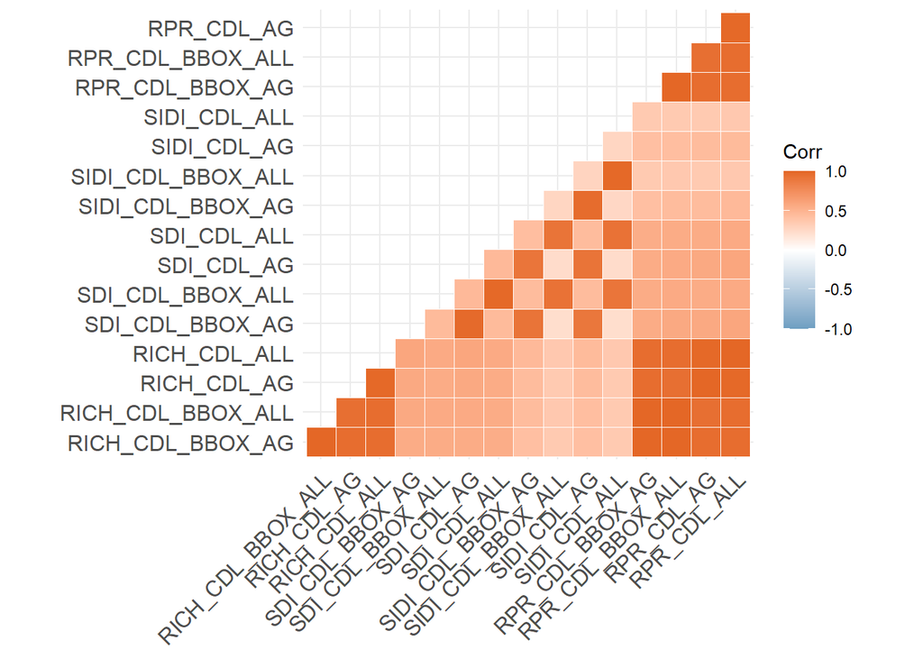

```r
library(ggcorrplot)
# visualize by "natural" groupings of variables
# third, diversity --
diversity <- yield[c(8:23)]
corr_div <- round(cor(diversity[c(1:16)]), 2)
p.mat_div <- cor_pmat(diversity[c(1:16)])
corrplot_div <- ggcorrplot(corr_div, hc.order = FALSE, p.mat = p.mat_div, outline.col = "white", type = "lower", insig = "blank",lab = F, ggtheme = ggplot2::theme_minimal, colors = c("#6D9EC1", "white", "#E46726"))
corrplot_div
```

```r
# let's immediately keep only _AG columns
diversity <- diversity[c(3,7,11,15)]

# see initial correlations
red_div <- as.data.frame(as.table(cor(diversity[c(1:4)]), 1))
red_div <- red_div %>%  filter(Freq != 1) %>% mutate(aFreq = abs(Freq)) %>% arrange(desc(aFreq)) %>% filter(aFreq > 0.80) %>% dplyr::select(c(Var1, Var2, Freq))

knitr::kable(red_div, caption = "Diversity variable pairs with high correlation")
```

Diversity variable pairs with high correlation

| Var1 | Var2 | Freq |
| --- | --- | --- |
| SIDI_CDL_AG | SDI_CDL_AG | 0.9247129 |
| SDI_CDL_AG | SIDI_CDL_AG | 0.9247129 |

```r
# all of these variables are essentially trying to say the same thing; let's keep SDI, cause it's what is most commonly used in the literature
div_quant <- as.data.frame(diversity[c(2)])
div_final_variables <- c("SDI_CDL_AG")
```

Drop:

- all ’_ALL’ variables
- all ’_BBOX’ variables
- SIDI_CDL_AG, RICH_CDL_AG, RPR_CDL_AG

Variables removed by KS/EB that I did not remove, below:

EB: NA

KS: NA

### Pair-Wise Correlation Matrix ~ farm(er) characteristics

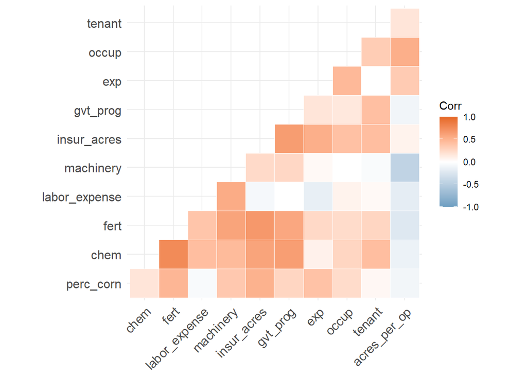

```r
# visualize by "natural" groupings of variables
# fourth, farm(er) characteristics --
farm <- yield[c(61:71)]
corr_farm <- round(cor(farm[c(1:11)]), 2)
p.mat_farm <- cor_pmat(farm[c(1:11)])
corrplot_farm <- ggcorrplot(corr_farm, hc.order = FALSE, p.mat = p.mat_farm, outline.col = "white", type = "lower", insig = "blank",lab = F, ggtheme = ggplot2::theme_minimal, colors = c("#6D9EC1", "white", "#E46726"))
corrplot_farm
```

```r
# see initial correlations
red_farm <- as.data.frame(as.table(cor(farm[c(1:11)]), 1))
red_farm <- red_farm %>%  filter(Freq != 1) %>% mutate(aFreq = abs(Freq)) %>% arrange(desc(aFreq)) %>% filter(aFreq > 0.80) %>% dplyr::select(c(Var1, Var2, Freq))

#knitr::kable(red_farm, caption = "Farm(er) variable pairs with high correlation")

# all of these variables are essentially trying to say the same thing; let's keep SDI, cause it's what is most commonly used in the literature
farm_quant <- as.data.frame(farm[c(1:11)])
farm_final_variables <- c("perc_corn","chem","fert","labor_expense","machinery","insur_acres","gvt_prog","exp","occup","tenant","acres_per_op")
```

## Pull together all variables we are keeping

```r
yield_keep <- yield %>% dplyr::select(c(GEOID,YEAR,YIELD,SDI_CDL_AG,GDD,TP,BV2,BV4,BV8,BV9,BV15,BV18,BV19,SLOPE,ELEVATION,S_PH_H2O,T_CACO3,T_CASO4,T_CEC_CLAY,T_CEC_SOIL,T_ESP,T_GRAVEL,T_OC,T_REF_BULK_DENSITY,T_SILT,T_ECE,T_SAND,PERC_IRR,FRR,perc_corn,chem,fert,labor_expense,machinery,insur_acres,gvt_prog,exp,occup,tenant,acres_per_op))

saveRDS(yield_keep, "./data/yieldRF.RDS")
```

## Pair-wise Correlation Values of Initial Variable Selection

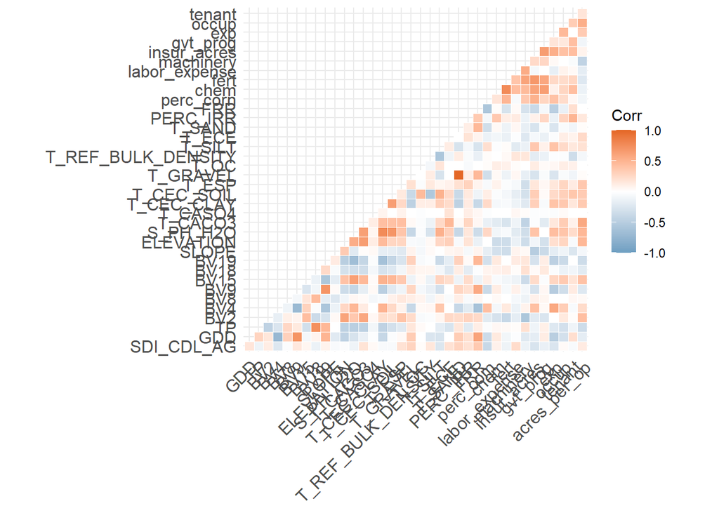

```r
red <- as.data.frame(as.table(cor(yield_keep[4:40]), 1))
red <- red %>% filter(Freq != 1) %>% mutate(aFreq = abs(Freq)) %>% arrange(desc(aFreq)) %>% filter(aFreq > 0.80) %>% dplyr::select(c(Var1, Var2, Freq))

# show correlations
yield_keep <- yield_keep[complete.cases(yield_keep), ]
corr_yield <- round(cor(yield_keep[c(4:40)]), 2)
p.mat_yield <- cor_pmat(yield_keep[c(4:40)])
corrplot_yield <- ggcorrplot(corr_yield, hc.order = FALSE, p.mat = p.mat_yield, outline.col = "white", type = "lower", insig = "blank",lab = F, ggtheme = ggplot2::theme_minimal, colors = c("#6D9EC1", "white", "#E46726"))
corrplot_yield
```

```r
yield_keep_corr <- as.data.frame(as.table(cor(yield_keep[c(4:40)]), 1))
yield_keep_corr
```

```
##                    Var1               Var2         Freq
## 1            SDI_CDL_AG         SDI_CDL_AG  1.000000000
## 2                   GDD         SDI_CDL_AG  0.165583237
## 3                    TP         SDI_CDL_AG -0.118574757
## 4                   BV2         SDI_CDL_AG  0.122128702
## 5                   BV4         SDI_CDL_AG -0.240703454
## 6                   BV8         SDI_CDL_AG -0.027742743
## 7                   BV9         SDI_CDL_AG  0.149029442
## 8                  BV15         SDI_CDL_AG  0.061723110
## 9                  BV18         SDI_CDL_AG -0.133802983
## 10                 BV19         SDI_CDL_AG  0.079779516
## 11                SLOPE         SDI_CDL_AG -0.048291031
## 12            ELEVATION         SDI_CDL_AG -0.033976187
## 13             S_PH_H2O         SDI_CDL_AG -0.111272577
## 14              T_CACO3         SDI_CDL_AG  0.180829552
```

[output cut: 1355 more lines]

###Remove collinear variables **Rules of elimination:

1. Drop any climate variable that measure a range, retain the min and max values
2. Drop any climate variable that is a monthly measurement and retain quarterly measurement
3. Drop any climate variable that is an annual summary
4. Keep crop-specific variables when collinear with biovars
5. Drop any soil variables that were ranked less important by J. Cowan
6. Choose the variable with the higher availability for other variable pairs